# Case Study Unit #8: Classification Using XGBoost, Random Forest & SVM

By: Armando Vela & Jeff Washburn

Date: 10/20/2020

### Abstract

A classification model was used to predict a binary target variable of an anonymized dataset provided by the case study. The three methods used were eXtreme Gradient Boosting (XGBoost), Random Forest, & Support Vector Machine (SVM). After running each model and comparing the accuracy for each, the XGBoost model was considered the best fitting model with an accuracy score of about 0.78. For future research, we may be able to increase our scores by looking into using Principal Component Analysis on the data as well as hyperparameter tuning.

### Introduction

For this case study, we were given an anonymized dataset that contained no metadata or data dictionary, with the only labeled column being our "target" variable. The dataset consisted of 114,321 rows and 133 columns (114 numeric vs 19 categorical). See figure 1 for a breakdown of the dataset.

```python
print("Figure 1: Breakdown of the dataset\n")

df.info()
```

```
Figure 1: Breakdown of the dataset

<class 'pandas.core.frame.DataFrame'>
RangeIndex: 114321 entries, 0 to 114320
Columns: 133 entries, ID to v131
dtypes: float64(108), int64(6), object(19)
memory usage: 116.0+ MB
```

With that said, the requirements for a successful study were as follows:

- Build 3 tuned models: XGBoost, Random Forest, SVM
- Show log loss and accuracy for XGBoost & Random Forest on out of fold predictions.
- Show accuracy for SVM on a validation set.
- Time how long it takes to do a sample of 1000, 2000, 5000, 10,000 rows in the SVM. What is the rough scaling of SVM with sample size?

Within the Methods section we will go over the basics of each model, the associated metrics to score the model fit, and how we prepared & modeled the data.

### Methods

###### Model Review

*XGBoost:*  
XGBoost is an optimized distributed gradient boosting library designed to be highly efficient, flexible and portable. It implements machine learning algorithms under the Gradient Boosting framework. XGBoost provides a parallel tree boosting (also known as GBDT, GBM) that solve many data science problems in a fast and accurate way

Reference: [XGBoost website](https://xgboost.readthedocs.io/en/latest/index.html)

*Random Forest:*  
Random forest consists of a large number of individual decision trees that operate as an ensemble. Each individual tree in the random forest spits out a class prediction and the class with the most votes becomes our model’s prediction

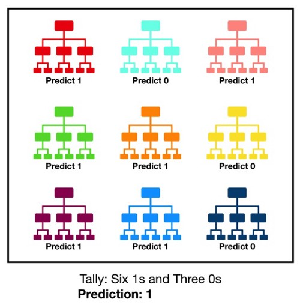

Reference: Tony Yiu - [Understanding Random Forest](https://towardsdatascience.com/understanding-random-forest-58381e0602d2)

*SVM:*  
The objective of the support vector machine algorithm is to find a hyperplane in an N-dimensional space(N — the number of features) that distinctly classifies the data points.

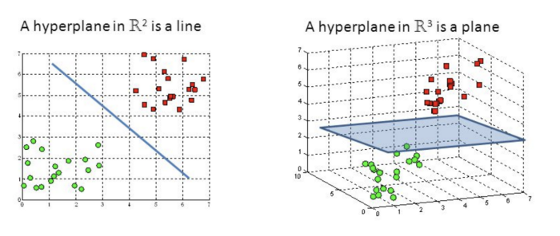

Refernce: Rohith Gandhi - [Support Vector Machine - Introduction to Machine Learning Algorithms](https://towardsdatascience.com/support-vector-machine-introduction-to-machine-learning-algorithms-934a444fca47)

###### Scoring Metrics

*LogLoss:*  
A measure of the difference between two probability distributions for a given random variable or set of events. Reference: [TowardsDataScience](https://towardsdatascience.com/log-loss-function-math-explained-5b83cd8d9c83)

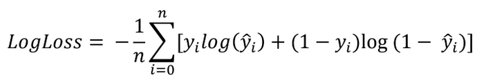

*Accuracy:*  
Accuracy is closeness of the measurements to a specific value. Reference: [Accuracy Definition](https://en.wikipedia.org/wiki/Accuracy_and_precision)

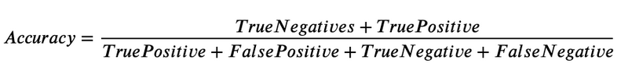

###### Preparing & Modeling the Data

*Initial Split:*  
The data was split into a training and test set using a stratified shuffle split before further analysis was done. A stratified shuffle split was used since the ratio of target = 1 vs target = 0 is skewed 76% to 24% respectively. See figure 2 below.

Reasoning for initial split: In the event that we are going to be sending out this model to production, by splitting out an initial test set we can train and cross validate our model with the training set and if we recieved acceptable scoring metrics then we can further test against the test set before sending out to production.

```
Figure 2: Breakdown of the target variable
```

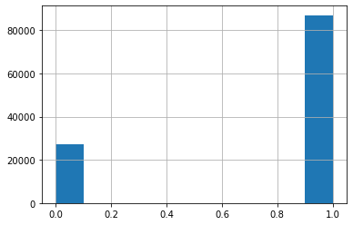

```python
print("Figure 2: Breakdown of the target variable \n")

df['target'].hist()
```

*PreProcessing Training Data:*  
In order to be able to run our models correctly, we needed to perform some data transformation methods prior to any models being created. With that said, we elected to use the StandardScaler method for our numerical values and OneHotEncoding for our categorical values.

### Results

See figure below displaying the scores for each model.

```python
print("Figure 5: Table of LogLoss and Accuracy Scores \n")
resultsDf
```

```
Figure 5: Table of LogLoss and Accuracy Scores
```

|  | ClassificationMethod | Accuracy | LogLoss | TrainingSize | TrainingDurationInSecs |
| --- | --- | --- | --- | --- | --- |
| 0 | XGBoost-xgb.XGBClassifier | 0.780876 | 0.473322 | 73164 | 72.153710 |
| 1 | RandomForest | 0.778320 | 0.485789 | 73164 | 168.968346 |
| 2 | Linear SVM-all | 0.777842 | NaN | 73164 | 166.025617 |

```
Figure 6: Chart of Accuracy Scores
```

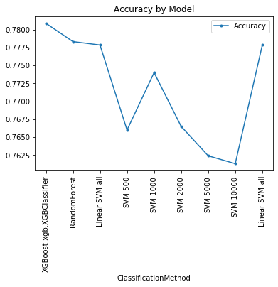

```python
print("Figure 6: Chart of Accuracy Scores \n")
combinedResultsDf.plot(x="ClassificationMethod", y="Accuracy", kind="line", style=".-", rot=90)
plt.title('Accuracy by Model')
plt.show()
```

Regarding the scaling of SVM with sample size, our time estimates are listed in the table below for each size. As you will notice, as the sample size increases the amount of time it takes for the SVM model to run substantially increases.

```python
print("Figure 7: Table of Times by Sample Sizes \n")
svmResultsDf
```

```
Figure 7: Table of Times by Sample Sizes
```

|  | ClassificationMethod | Accuracy | LogLoss | TrainingSize | TrainingDurationInSecs |
| --- | --- | --- | --- | --- | --- |
| 0 | SVM-500 | 0.766000 | NaN | 500 | 0.148038 |
| 1 | SVM-1000 | 0.774000 | NaN | 1000 | 0.659542 |
| 2 | SVM-2000 | 0.766500 | NaN | 2000 | 2.271055 |
| 3 | SVM-5000 | 0.762400 | NaN | 5000 | 12.926196 |
| 4 | SVM-10000 | 0.761300 | NaN | 10000 | 59.815685 |
| 5 | Linear SVM-all | 0.777842 | NaN | 73164 | 166.025617 |

```
Figure 8: Chart of Times
```

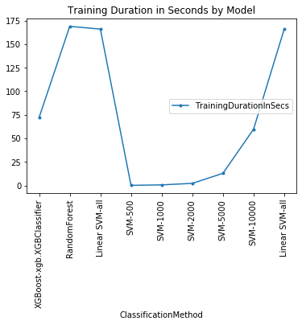

```python
print("Figure 8: Chart of Times \n")
combinedResultsDf.plot(x="ClassificationMethod", y=["TrainingDurationInSecs"], kind="line", style=".-", rot=90)
plt.title('Training Duration in Seconds by Model')
plt.show()
```

### Conclusion

In conclusion, we have met the proposed requirements of the case study. This includes running three different model types, acquiring the associated scores, and discussing the time complexity when it comes to SVMs. With that said, there are still aspects that can be improved upon such as using PCA on the data and further tuning our parameters within each model.

## Appendix A: Code Details

#### Import necessary libraries and read in csv file

```python
import pandas as pd
import numpy as np
import matplotlib.pyplot as plt

from sklearn.model_selection import StratifiedShuffleSplit

from sklearn.compose import ColumnTransformer
from sklearn.pipeline import Pipeline
from sklearn.preprocessing import StandardScaler
from sklearn.preprocessing import OneHotEncoder
from sklearn import set_config
set_config(display='diagram')

from sklearn.model_selection import train_test_split

from sklearn.ensemble import RandomForestClassifier

from sklearn.model_selection import GridSearchCV

from sklearn.model_selection import StratifiedKFold
from sklearn.model_selection import cross_val_score

from sklearn.metrics import log_loss, accuracy_score

from sklearn.model_selection import cross_validate

import xgboost as xgb
from sklearn.svm import LinearSVC

import time
```

```python
df = pd.read_csv('case_8.csv')
```

# EDA - Quick look at data structure

```python
df.head()
```

|  | ID | target | v1 | v2 | v3 | v4 | v5 | v6 | v7 | v8 | ... | v122 | v123 | v124 | v125 | v126 | v127 | v128 | v129 | v130 | v131 |
| --- | --- | --- | --- | --- | --- | --- | --- | --- | --- | --- | --- | --- | --- | --- | --- | --- | --- | --- | --- | --- | --- |
| 0 | 3 | 1 | 1.335739 | 8.727474 | C | 3.921026 | 7.915266 | 2.599278 | 3.176895 | 0.012941 | ... | 8.000000 | 1.989780 | 0.035754 | AU | 1.804126 | 3.113719 | 2.024285 | 0 | 0.636365 | 2.857144 |
| 1 | 4 | 1 | 1.630686 | 7.464411 | C | 4.145098 | 9.191265 | 2.436402 | 2.483921 | 2.301630 | ... | 6.822439 | 3.549938 | 0.598896 | AF | 1.672658 | 3.239542 | 1.957825 | 0 | 1.925763 | 1.739389 |
| 2 | 5 | 1 | 0.943877 | 5.310079 | C | 4.410969 | 5.326159 | 3.979592 | 3.928571 | 0.019645 | ... | 9.333333 | 2.477596 | 0.013452 | AE | 1.773709 | 3.922193 | 1.120468 | 2 | 0.883118 | 1.176472 |
| 3 | 6 | 1 | 0.797415 | 8.304757 | C | 4.225930 | 11.627438 | 2.097700 | 1.987549 | 0.171947 | ... | 7.018256 | 1.812795 | 0.002267 | CJ | 1.415230 | 2.954381 | 1.990847 | 1 | 1.677108 | 1.034483 |
| 4 | 8 | 1 | 1.630686 | 7.464411 | C | 4.145098 | 8.742359 | 2.436402 | 2.483921 | 1.496569 | ... | 6.822439 | 3.549938 | 0.919812 | Z | 1.672658 | 3.239542 | 2.030373 | 0 | 1.925763 | 1.739389 |

5 rows × 133 columns

```python
df.describe()
```

|  | ID | target | v1 | v2 | v4 | v5 | v6 | v7 | v8 | v9 | ... | v121 | v122 | v123 | v124 | v126 | v127 | v128 | v129 | v130 | v131 |
| --- | --- | --- | --- | --- | --- | --- | --- | --- | --- | --- | --- | --- | --- | --- | --- | --- | --- | --- | --- | --- | --- |
| count | 114321.000000 | 114321.000000 | 1.143210e+05 | 1.143210e+05 | 1.143210e+05 | 1.143210e+05 | 1.143210e+05 | 1.143210e+05 | 1.143210e+05 | 1.143210e+05 | ... | 1.143210e+05 | 1.143210e+05 | 114321.000000 | 1.143210e+05 | 1.143210e+05 | 1.143210e+05 | 1.143210e+05 | 114321.000000 | 1.143210e+05 | 1.143210e+05 |
| mean | 114228.928228 | 0.761199 | 1.630686e+00 | 7.464411e+00 | 4.145098e+00 | 8.742359e+00 | 2.436402e+00 | 2.483921e+00 | 1.496569e+00 | 9.031859e+00 | ... | 2.737596e+00 | 6.822439e+00 | 3.549938 | 9.198120e-01 | 1.672658e+00 | 3.239542e+00 | 2.030373e+00 | 0.310144 | 1.925763e+00 | 1.739389e+00 |
| std | 65934.487362 | 0.426353 | 8.132649e-01 | 2.225036e+00 | 8.626621e-01 | 1.543441e+00 | 4.506138e-01 | 4.427150e-01 | 2.109786e+00 | 1.449542e+00 | ... | 1.018603e+00 | 1.348700e+00 | 1.943431 | 1.591555e+00 | 3.779128e-01 | 1.221225e+00 | 8.143413e-01 | 0.693262 | 9.496402e-01 | 8.518204e-01 |
| min | 3.000000 | 0.000000 | -9.996497e-07 | -9.817614e-07 | -6.475929e-07 | -5.287068e-07 | -9.055091e-07 | -9.468765e-07 | -7.783778e-07 | -9.828757e-07 | ... | -9.820642e-07 | -9.978497e-07 | 0.019139 | -9.994953e-07 | -9.564174e-07 | -9.223798e-07 | 8.197812e-07 | 0.000000 | -9.901257e-07 | -9.999134e-07 |
| 25% | 57280.000000 | 1.000000 | 1.346153e+00 | 6.575770e+00 | 4.068697e+00 | 8.394090e+00 | 2.340968e+00 | 2.376586e+00 | 2.653147e-01 | 8.813560e+00 | ... | 2.282609e+00 | 6.519607e+00 | 2.571053 | 8.471320e-02 | 1.570974e+00 | 2.762497e+00 | 1.681261e+00 | 0.000000 | 1.449477e+00 | 1.463414e+00 |
| 50% | 114189.000000 | 1.000000 | 1.630686e+00 | 7.464411e+00 | 4.145098e+00 | 8.742359e+00 | 2.436402e+00 | 2.483921e+00 | 1.496569e+00 | 9.031859e+00 | ... | 2.737596e+00 | 6.822439e+00 | 3.549938 | 9.198120e-01 | 1.672658e+00 | 3.239542e+00 | 2.030373e+00 | 0.000000 | 1.925763e+00 | 1.739389e+00 |
| 75% | 171206.000000 | 1.000000 | 1.630686e+00 | 7.551501e+00 | 4.340229e+00 | 8.924798e+00 | 2.484699e+00 | 2.528445e+00 | 1.496569e+00 | 9.302325e+00 | ... | 2.737596e+00 | 6.999999e+00 | 3.549938 | 9.198120e-01 | 1.672658e+00 | 3.239542e+00 | 2.030373e+00 | 0.000000 | 1.925763e+00 | 1.739389e+00 |
| max | 228713.000000 | 1.000000 | 2.000000e+01 | 2.000000e+01 | 2.000000e+01 | 2.000000e+01 | 2.000000e+01 | 2.000000e+01 | 2.000000e+01 | 2.000000e+01 | ... | 2.000000e+01 | 2.000000e+01 | 19.686069 | 2.000000e+01 | 1.563161e+01 | 2.000000e+01 | 2.000000e+01 | 11.000000 | 2.000000e+01 | 2.000000e+01 |

8 rows × 114 columns

```python
df.info()
```

```
<class 'pandas.core.frame.DataFrame'>
RangeIndex: 114321 entries, 0 to 114320
Columns: 133 entries, ID to v131
dtypes: float64(108), int64(6), object(19)
memory usage: 116.0+ MB
```

#### Identify if there are any skewness in the target variable. (ie. is one value overwhelmingly showing within the dataset)

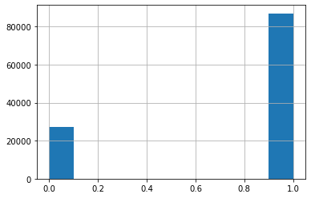

```python
df['target'].hist()
```

```python
df['target'].value_counts()
```

```
1    87021
0    27300
Name: target, dtype: int64
```

```python
df['target'].value_counts() / len(df['target'])
```

```
1    0.761199
0    0.238801
Name: target, dtype: float64
```

# Prepare Data

## Split the data into train and test set

The data will be split into a training and test set before further analysis will be done. With that said, since the ratio of target = 1 vs target = 0 is skewed 76% to 24% respectively, we will be performing a stratified shuffle spit on the data.

Note: this test set is not to be touched until we are close to final production. In other words, we will be using the training set to train and cross validate our model. Once we have recieved a good enough accuracy, then we can try on the test set before sending out to production.

```python
split = StratifiedShuffleSplit(n_splits=1, test_size=0.2, random_state=50)

for train_index, test_index in split.split(df, df['target']):
    strat_train_set = df.loc[train_index]
    strat_test_set = df.loc[test_index]
```

```python
strat_test_set['target'].value_counts() / len(strat_test_set['target'])
```

```
1    0.761207
0    0.238793
Name: target, dtype: float64
```

### Begin analysis on training data. Check if there are any NAs in the data.

```python
# copy over the training set so that we can begin our analysis
caseDf = strat_train_set.copy()
```

```python
x = caseDf.describe()
xT = x.transpose()
xT
```

|  | count | mean | std | min | 25% | 50% | 75% | max |
| --- | --- | --- | --- | --- | --- | --- | --- | --- |
| ID | 91456.0 | 114173.849950 | 65983.626432 | 3.000000e+00 | 57056.750000 | 113975.000000 | 171217.500000 | 228713.000000 |
| target | 91456.0 | 0.761197 | 0.426355 | 0.000000e+00 | 1.000000 | 1.000000 | 1.000000 | 1.000000 |
| v1 | 91456.0 | 1.629992 | 0.810523 | -9.996497e-07 | 1.346434 | 1.630686 | 1.630686 | 20.000001 |
| v2 | 91456.0 | 7.469810 | 2.224945 | -9.817614e-07 | 6.588979 | 7.464411 | 7.565553 | 20.000000 |
| v4 | 91456.0 | 4.146902 | 0.861221 | -6.475929e-07 | 4.072277 | 4.145098 | 4.341303 | 11.831779 |
| ... | ... | ... | ... | ... | ... | ... | ... | ... |
| v127 | 91456.0 | 3.239546 | 1.221690 | -9.223798e-07 | 2.761930 | 3.239542 | 3.239542 | 17.602042 |
| v128 | 91456.0 | 2.032677 | 0.820000 | 8.197812e-07 | 1.684745 | 2.030373 | 2.030373 | 20.000000 |
| v129 | 91456.0 | 0.310805 | 0.695372 | 0.000000e+00 | 0.000000 | 0.000000 | 0.000000 | 11.000000 |
| v130 | 91456.0 | 1.923290 | 0.947437 | -9.901257e-07 | 1.445723 | 1.925763 | 1.925763 | 20.000000 |
| v131 | 91456.0 | 1.741581 | 0.853535 | -9.999134e-07 | 1.463415 | 1.739389 | 1.739389 | 20.000001 |

114 rows × 8 columns

```python
xT[xT['count'] !=91456]
```

|  | count | mean | std | min | 25% | 50% | 75% | max |
| --- | --- | --- | --- | --- | --- | --- | --- | --- |

### No NAs found, so imputations not needed. Next checking for correlations against target variable.

```python
corr_matrix = caseDf.corr()
```

```python
corr_target = pd.DataFrame(corr_matrix['target'])
corr_target['absCorrelation'] = abs(corr_target['target'])
```

After reviewing the top 15 correlations against the target variable, we cannot reasonably state that one specific variable is highly correlated with the target variable.

```python
corr_target.sort_values(by='absCorrelation', ascending=False).head(n=15)
```

|  | target | absCorrelation |
| --- | --- | --- |
| target | 1.000000 | 1.000000 |
| v50 | 0.242870 | 0.242870 |
| v10 | 0.149665 | 0.149665 |
| v129 | 0.142656 | 0.142656 |
| v14 | 0.131478 | 0.131478 |
| v34 | 0.096754 | 0.096754 |
| v62 | -0.094842 | 0.094842 |
| v114 | 0.075966 | 0.075966 |
| v72 | 0.075704 | 0.075704 |
| v21 | 0.068546 | 0.068546 |
| v38 | 0.063188 | 0.063188 |
| v12 | 0.055600 | 0.055600 |
| v4 | 0.045057 | 0.045057 |
| v119 | -0.044960 | 0.044960 |
| v123 | -0.042899 | 0.042899 |

### Separate training dataset into two dataframes (One for features (ie Independent Variables) while the other has just the target variable (ie Labels)).

This is extra step is just to ensure that any Scaling or OneHotEncoding done to our features will not affect the target variable.

```python
caseDfIndependents = strat_train_set.drop('target', axis=1)
caseDfLabels = strat_train_set['target'].copy()
```

#### Separate Independent dataframe between numeric and categorical features.

```python
# display dataframe information
caseDfIndependents.info()
```

```
<class 'pandas.core.frame.DataFrame'>
Int64Index: 91456 entries, 59407 to 14152
Columns: 132 entries, ID to v131
dtypes: float64(108), int64(5), object(19)
memory usage: 92.8+ MB
```

```python
#create new dataframe that only includes categorical features
caseDfIndependents_Cat = caseDfIndependents.select_dtypes(exclude=[np.number])
caseDfIndependents_Cat.describe()
```

|  | v3 | v22 | v24 | v30 | v31 | v47 | v52 | v56 | v66 | v71 | v74 | v75 | v79 | v91 | v107 | v110 | v112 | v113 | v125 |
| --- | --- | --- | --- | --- | --- | --- | --- | --- | --- | --- | --- | --- | --- | --- | --- | --- | --- | --- | --- |
| count | 91456 | 91456 | 91456 | 91456 | 91456 | 91456 | 91456 | 91456 | 91456 | 91456 | 91456 | 91456 | 91456 | 91456 | 91456 | 91456 | 91456 | 91456 | 91456 |
| unique | 3 | 16614 | 5 | 7 | 3 | 10 | 12 | 117 | 3 | 9 | 3 | 4 | 18 | 7 | 7 | 3 | 22 | 36 | 90 |
| top | C | AGDF | E | C | A | C | J | BW | A | F | B | D | C | A | E | A | F | G | BM |
| freq | 91223 | 2288 | 44135 | 73896 | 73413 | 44320 | 8894 | 14501 | 56262 | 60053 | 90827 | 60047 | 27597 | 21618 | 21618 | 44541 | 17669 | 57309 | 4636 |

```python
#create new dataframe that only includes numeric features
caseDfIndependents_Num = caseDfIndependents.select_dtypes(include=[np.number])
caseDfIndependents_Num.describe()
```

|  | ID | v1 | v2 | v4 | v5 | v6 | v7 | v8 | v9 | v10 | ... | v121 | v122 | v123 | v124 | v126 | v127 | v128 | v129 | v130 | v131 |
| --- | --- | --- | --- | --- | --- | --- | --- | --- | --- | --- | --- | --- | --- | --- | --- | --- | --- | --- | --- | --- | --- |
| count | 91456.000000 | 9.145600e+04 | 9.145600e+04 | 9.145600e+04 | 9.145600e+04 | 9.145600e+04 | 9.145600e+04 | 9.145600e+04 | 9.145600e+04 | 9.145600e+04 | ... | 9.145600e+04 | 9.145600e+04 | 91456.000000 | 9.145600e+04 | 9.145600e+04 | 9.145600e+04 | 9.145600e+04 | 91456.000000 | 9.145600e+04 | 9.145600e+04 |
| mean | 114173.849950 | 1.629992e+00 | 7.469810e+00 | 4.146902e+00 | 8.746779e+00 | 2.436468e+00 | 2.484323e+00 | 1.492311e+00 | 9.029981e+00 | 1.885229e+00 | ... | 2.733666e+00 | 6.823168e+00 | 3.546549 | 9.172868e-01 | 1.672350e+00 | 3.239546e+00 | 2.032677e+00 | 0.310805 | 1.923290e+00 | 1.741581e+00 |
| std | 65983.626432 | 8.105228e-01 | 2.224945e+00 | 8.612210e-01 | 1.544729e+00 | 4.484554e-01 | 4.443687e-01 | 2.103106e+00 | 1.452556e+00 | 1.396429e+00 | ... | 1.016370e+00 | 1.352595e+00 | 1.942478 | 1.590902e+00 | 3.808063e-01 | 1.221690e+00 | 8.200000e-01 | 0.695372 | 9.474373e-01 | 8.535354e-01 |
| min | 3.000000 | -9.996497e-07 | -9.817614e-07 | -6.475929e-07 | -5.287068e-07 | -7.915270e-07 | -9.468765e-07 | -7.783778e-07 | -9.828757e-07 | -9.875317e-07 | ... | -9.362938e-07 | -9.978497e-07 | 0.062938 | -9.994953e-07 | -6.413297e-07 | -9.223798e-07 | 8.197812e-07 | 0.000000 | -9.901257e-07 | -9.999134e-07 |
| 25% | 57056.750000 | 1.346434e+00 | 6.588979e+00 | 4.072277e+00 | 8.399461e+00 | 2.341221e+00 | 2.378243e+00 | 2.643136e-01 | 8.809523e+00 | 1.050328e+00 | ... | 2.275354e+00 | 6.519338e+00 | 2.567885 | 8.455682e-02 | 1.570583e+00 | 2.761930e+00 | 1.684745e+00 | 0.000000 | 1.445723e+00 | 1.463415e+00 |
| 50% | 113975.000000 | 1.630686e+00 | 7.464411e+00 | 4.145098e+00 | 8.742359e+00 | 2.436402e+00 | 2.483921e+00 | 1.496569e+00 | 9.031859e+00 | 1.312910e+00 | ... | 2.737596e+00 | 6.822439e+00 | 3.549938 | 9.198120e-01 | 1.672658e+00 | 3.239542e+00 | 2.030373e+00 | 0.000000 | 1.925763e+00 | 1.739389e+00 |
| 75% | 171217.500000 | 1.630686e+00 | 7.565553e+00 | 4.341303e+00 | 8.925911e+00 | 2.483552e+00 | 2.528862e+00 | 1.496569e+00 | 9.293680e+00 | 2.100657e+00 | ... | 2.737596e+00 | 6.994535e+00 | 3.549938 | 9.198120e-01 | 1.672658e+00 | 3.239542e+00 | 2.030373e+00 | 0.000000 | 1.925763e+00 | 1.739389e+00 |
| max | 228713.000000 | 2.000000e+01 | 2.000000e+01 | 1.183178e+01 | 2.000000e+01 | 2.000000e+01 | 2.000000e+01 | 2.000000e+01 | 2.000000e+01 | 1.853392e+01 | ... | 2.000000e+01 | 2.000000e+01 | 18.252446 | 2.000000e+01 | 1.563161e+01 | 1.760204e+01 | 2.000000e+01 | 11.000000 | 2.000000e+01 | 2.000000e+01 |

8 rows × 113 columns

#### For our pre-processing pipeline, create lists of numerical features and categorical features that will be used in the models.

```python
num_attribs = list(caseDfIndependents_Num)
num_attribs.remove('ID')
#num_attribs

cat_attribs = list(caseDfIndependents_Cat)
removals = ['v22','v52', 'v56', 'v79', 'v112', 'v113','v125']
#cat_attribs

# Remove all cat from list
for i in removals:
    cat_attribs.remove(i)
```

#### Setup our pre-processing pipelines.

For **preprocessor** this includes using a StandardScaler for numerical attributes and OneHotEncoding categorical attributes.

```python
preprocessor = ColumnTransformer([
    ('num', StandardScaler(), num_attribs),
    ('cat', OneHotEncoder(), cat_attribs)],
    remainder = 'drop'
)
```

# Conduct classification analysis using XGBoost, RandomForest, & SVM

```python
# Prepare data using preprocessor pipeline
caseDfIndependents_prepared = preprocessor.fit_transform(caseDfIndependents)

# Split training dataframe into train/test set
X_train, X_test, y_train, y_test = train_test_split(caseDfIndependents_prepared, caseDfLabels,
                                                    test_size=0.20, random_state=100)
```

```python
# Print info on the X_train
print("X_train info")
print(type(X_train))
pd.DataFrame(X_train).describe()
```

```
X_train info
<class 'numpy.ndarray'>
```

|  | 0 | 1 | 2 | 3 | 4 | 5 | 6 | 7 | 8 | 9 | ... | 166 | 167 | 168 | 169 | 170 | 171 | 172 | 173 | 174 | 175 |
| --- | --- | --- | --- | --- | --- | --- | --- | --- | --- | --- | --- | --- | --- | --- | --- | --- | --- | --- | --- | --- | --- |
| count | 73164.000000 | 73164.000000 | 73164.000000 | 73164.000000 | 73164.000000 | 73164.000000 | 73164.000000 | 73164.000000 | 73164.000000 | 73164.000000 | ... | 73164.000000 | 73164.000000 | 73164.000000 | 73164.000000 | 73164.000000 | 73164.000000 | 73164.000000 | 73164.000000 | 73164.000000 | 73164.000000 |
| mean | -0.001190 | 0.001122 | 0.000431 | 0.001470 | -0.001535 | 0.001314 | -0.001363 | -0.000173 | -0.004706 | 0.002349 | ... | 0.117544 | 0.197050 | 0.214327 | 0.204527 | 0.235936 | 0.028621 | 0.001996 | 0.486592 | 0.485321 | 0.028088 |
| std | 1.000344 | 0.999276 | 1.000003 | 1.000824 | 1.002750 | 0.999157 | 0.997506 | 0.997685 | 0.993888 | 0.991729 | ... | 0.322070 | 0.397773 | 0.410357 | 0.403358 | 0.424585 | 0.166739 | 0.044627 | 0.499824 | 0.499788 | 0.165224 |
| min | -2.011051 | -3.357319 | -4.815169 | -5.662369 | -5.433052 | -5.590712 | -0.709579 | -6.216650 | -1.350043 | -26.013362 | ... | 0.000000 | 0.000000 | 0.000000 | 0.000000 | 0.000000 | 0.000000 | 0.000000 | 0.000000 | 0.000000 | 0.000000 |
| 25% | -0.349849 | -0.389949 | -0.083721 | -0.216135 | -0.216380 | -0.236150 | -0.584047 | -0.151050 | -0.597886 | -0.072262 | ... | 0.000000 | 0.000000 | 0.000000 | 0.000000 | 0.000000 | 0.000000 | 0.000000 | 0.000000 | 0.000000 | 0.000000 |
| 50% | 0.000855 | -0.002426 | -0.002095 | -0.002861 | -0.000147 | -0.000906 | 0.002024 | 0.001293 | -0.409846 | -0.000899 | ... | 0.000000 | 0.000000 | 0.000000 | 0.000000 | 0.000000 | 0.000000 | 0.000000 | 0.000000 | 0.000000 | 0.000000 |
| 75% | 0.000855 | 0.048542 | 0.224955 | 0.115244 | 0.097358 | 0.100765 | 0.002024 | 0.177460 | 0.154272 | 0.250248 | ... | 0.000000 | 0.000000 | 0.000000 | 0.000000 | 0.000000 | 0.000000 | 0.000000 | 1.000000 | 1.000000 | 0.000000 |
| max | 22.664518 | 5.631716 | 8.923284 | 7.284954 | 39.164711 | 39.417204 | 8.800218 | 7.552261 | 11.922393 | 7.665370 | ... | 1.000000 | 1.000000 | 1.000000 | 1.000000 | 1.000000 | 1.000000 | 1.000000 | 1.000000 | 1.000000 | 1.000000 |

8 rows × 176 columns

```python
# Print info on the X_test
print("X_test info")
print(type(X_test))
pd.DataFrame(X_test).describe()
```

```
X_test info
<class 'numpy.ndarray'>
```

|  | 0 | 1 | 2 | 3 | 4 | 5 | 6 | 7 | 8 | 9 | ... | 166 | 167 | 168 | 169 | 170 | 171 | 172 | 173 | 174 | 175 |
| --- | --- | --- | --- | --- | --- | --- | --- | --- | --- | --- | --- | --- | --- | --- | --- | --- | --- | --- | --- | --- | --- |
| count | 18292.000000 | 18292.000000 | 18292.000000 | 18292.000000 | 18292.000000 | 18292.000000 | 18292.000000 | 18292.000000 | 18292.000000 | 18292.000000 | ... | 18292.000000 | 18292.000000 | 18292.000000 | 18292.000000 | 18292.000000 | 18292.000000 | 18292.000000 | 18292.000000 | 18292.000000 | 18292.000000 |
| mean | 0.004762 | -0.004488 | -0.001726 | -0.005880 | 0.006139 | -0.005257 | 0.005452 | 0.000690 | 0.018825 | -0.009395 | ... | 0.119998 | 0.199978 | 0.214629 | 0.198502 | 0.238137 | 0.026897 | 0.001859 | 0.488738 | 0.481795 | 0.029466 |
| std | 0.998662 | 1.002932 | 1.000043 | 0.996728 | 0.988957 | 1.003402 | 1.009949 | 1.009259 | 1.023919 | 1.032422 | ... | 0.324968 | 0.399995 | 0.410576 | 0.398883 | 0.425955 | 0.161787 | 0.043074 | 0.499887 | 0.499682 | 0.169115 |
| min | -2.011051 | -3.292417 | -4.666676 | -4.930980 | -5.433050 | -5.303009 | -0.709579 | -6.216650 | -1.350043 | -26.013362 | ... | 0.000000 | 0.000000 | 0.000000 | 0.000000 | 0.000000 | 0.000000 | 0.000000 | 0.000000 | 0.000000 | 0.000000 |
| 25% | -0.349042 | -0.414956 | -0.096250 | -0.232407 | -0.195405 | -0.253059 | -0.583396 | -0.156680 | -0.597886 | -0.090996 | ... | 0.000000 | 0.000000 | 0.000000 | 0.000000 | 0.000000 | 0.000000 | 0.000000 | 0.000000 | 0.000000 | 0.000000 |
| 50% | 0.000855 | -0.002426 | -0.002095 | -0.002861 | -0.000147 | -0.000906 | 0.002024 | 0.001293 | -0.409846 | -0.000899 | ... | 0.000000 | 0.000000 | 0.000000 | 0.000000 | 0.000000 | 0.000000 | 0.000000 | 0.000000 | 0.000000 | 0.000000 |
| 75% | 0.000855 | 0.023281 | 0.227244 | 0.119085 | 0.119720 | 0.094963 | 0.002024 | 0.201915 | 0.279631 | 0.234490 | ... | 0.000000 | 0.000000 | 0.000000 | 0.000000 | 0.000000 | 0.000000 | 0.000000 | 1.000000 | 1.000000 | 0.000000 |
| max | 11.022201 | 5.373844 | 8.058168 | 7.284955 | 8.380416 | 14.412808 | 8.800218 | 7.552261 | 8.788407 | 7.665368 | ... | 1.000000 | 1.000000 | 1.000000 | 1.000000 | 1.000000 | 1.000000 | 1.000000 | 1.000000 | 1.000000 | 1.000000 |

8 rows × 176 columns

```python
# Print info on the y_train
print("y_train info")
print(type(y_train))
pd.DataFrame(y_train).describe()
```

```
y_train info
<class 'pandas.core.series.Series'>
```

|  | target |
| --- | --- |
| count | 73164.000000 |
| mean | 0.761249 |
| std | 0.426323 |
| min | 0.000000 |
| 25% | 1.000000 |
| 50% | 1.000000 |
| 75% | 1.000000 |
| max | 1.000000 |

```python
# Print info on the y_test
print("y_test info")
print(type(y_test))
pd.DataFrame(y_test).describe()
```

```
y_test info
<class 'pandas.core.series.Series'>
```

|  | target |
| --- | --- |
| count | 18292.000000 |
| mean | 0.760988 |
| std | 0.426491 |
| min | 0.000000 |
| 25% | 1.000000 |
| 50% | 1.000000 |
| 75% | 1.000000 |
| max | 1.000000 |

```python
# Store results in dataframe
resultsDf = pd.DataFrame(columns=['ClassificationMethod', 'Accuracy', 'LogLoss', 'TrainingSize', 'TrainingDurationInSecs'])
```

## XGBoost:

### XGBoost - GridSearch

Use GridSearch to identify best parameters.

```python
xgb_model = xgb.XGBClassifier()

grid_params_xgb = {
   "objective": ["binary:logistic"],
   "booster": ["gbtree"],
   "eval_metric": ["logloss"],
   "eta": [0.001, 0.01],
   "subsample": [0.5, 0.8],
   "colsample_bytree": [0.5, 0.8],
   "max_depth": [3, 14]
}

kfold = StratifiedKFold(n_splits=5)
gs_xgb = GridSearchCV(estimator=xgb_model,
                     param_grid=grid_params_xgb,
                     scoring='accuracy',
                     cv=kfold,
                     n_jobs=-1)
```

```python
gridSearchFit = gs_xgb.fit(X_train, y_train)
```

```python
gridSearchFit.cv_results_['mean_test_score']
```

```
array([0.78120387, 0.78129955, 0.77527199, 0.77811492, 0.78120387,
       0.78129955, 0.77527199, 0.77811492, 0.78065715, 0.78093051,
       0.7738642 , 0.77800558, 0.78065715, 0.78093051, 0.7738642 ,
       0.77800558])
```

```python
gridSearchFit.best_params_
```

```
{'booster': 'gbtree',
 'colsample_bytree': 0.5,
 'eta': 0.001,
 'eval_metric': 'logloss',
 'max_depth': 3,
 'objective': 'binary:logistic',
 'subsample': 0.8}
```

Run model with best fitting parameters.

```python
boost_round = 50

### another way to calculate the accuracy and logloss is below
model = xgb.XGBClassifier(objective = "binary:logistic",
                          booster = "gbtree",
                          eval_metric = "logloss",
                          eta = 0.001,
                          subsample = 0.8,
                          colsample_bytree = 0.5,
                          max_depth = 3,
                          num_boost_round=boost_round,
                          verbose_eval=True,
                          maximize=False)

kfold = StratifiedKFold(n_splits=5)
scoring = ['accuracy', 'neg_log_loss']

# Time how long to fit/train the model
xgBoostStart2 = time.perf_counter()

results = cross_validate(model, X_train, y_train, cv=kfold, scoring = scoring)

xgBoostDurationInSecs2 = time.perf_counter() - xgBoostStart2
```

```python
# update the results
resultsDf = resultsDf.append({'ClassificationMethod' : 'XGBoost-xgb.XGBClassifier' ,
                  'Accuracy' : results['test_accuracy'].mean(),
                  'LogLoss' : results['test_neg_log_loss'].mean() * -1,
                  'TrainingSize' : X_train.shape[0],
                  'TrainingDurationInSecs': xgBoostDurationInSecs2} , ignore_index=True)
```

```python
print("Accuracy: ", results['test_accuracy'].mean())
print("LogLoss: ", results['test_neg_log_loss'].mean() * -1)
resultsDf
```

```
Accuracy:  0.7808759033718621
LogLoss:  0.47332239989080527
```

|  | ClassificationMethod | Accuracy | LogLoss | TrainingSize | TrainingDurationInSecs |
| --- | --- | --- | --- | --- | --- |
| 0 | XGBoost-xgb.XGBClassifier | 0.780876 | 0.473322 | 73164 | 72.15371 |

## Random Forest:

```python
model = RandomForestClassifier(n_estimators=100)
kfold = StratifiedKFold(n_splits=5)
scoring = ['accuracy', 'neg_log_loss']

# Time it takes to fit/train the model
randomForestStart = time.perf_counter()

results = cross_validate(model, X_train, y_train, cv=kfold, scoring = scoring)

randomForestStartDurationInSecs = time.perf_counter() - randomForestStart
```

```python
# Update the Results
resultsDf = resultsDf.append({'ClassificationMethod' : 'RandomForest' ,
                  'Accuracy' : results['test_accuracy'].mean(),
                  'LogLoss' : results['test_neg_log_loss'].mean() * -1,
                  'TrainingSize' : X_train.shape[0],
                  'TrainingDurationInSecs': randomForestStartDurationInSecs} , ignore_index=True)
```

```python
print("Accuracy: ", results['test_accuracy'].mean())
print("LogLoss: ", results['test_neg_log_loss'].mean() * -1)
resultsDf
```

```
Accuracy:  0.7783199748450861
LogLoss:  0.485789458897118
```

|  | ClassificationMethod | Accuracy | LogLoss | TrainingSize | TrainingDurationInSecs |
| --- | --- | --- | --- | --- | --- |
| 0 | XGBoost-xgb.XGBClassifier | 0.780876 | 0.473322 | 73164 | 72.153710 |
| 1 | RandomForest | 0.778320 | 0.485789 | 73164 | 168.968346 |

## Linear SVM:

```python
### the following code takes quite a bit of time to run
modelSVC = LinearSVC(tol=2, max_iter = 5000)
kfold = StratifiedKFold(n_splits=5)
#scoring = ['accuracy', 'neg_log_loss']

# Takes 15 to 20 mins to run against the entire data set
start = time.perf_counter()

results = cross_validate(model, X_train, y_train, cv=kfold, scoring = 'accuracy')
duration = time.perf_counter() - start
```

```python
resultsDf = resultsDf.append({'ClassificationMethod' : 'Linear SVM-all' ,
                  'Accuracy' : results['test_score'].mean(),
                  'LogLoss' : np.nan,
                  'TrainingSize' : X_train.shape[0],
                  'TrainingDurationInSecs': duration} , ignore_index=True)
```

```python
print("Accuracy: ", results['test_score'].mean())
#print("LogLoss: ", results['test_neg_log_loss'].mean() * -1)
resultsDf
```

```
Accuracy:  0.7778416292600474
```

|  | ClassificationMethod | Accuracy | LogLoss | TrainingSize | TrainingDurationInSecs |
| --- | --- | --- | --- | --- | --- |
| 0 | XGBoost-xgb.XGBClassifier | 0.780876 | 0.473322 | 73164 | 72.153710 |
| 1 | RandomForest | 0.778320 | 0.485789 | 73164 | 168.968346 |
| 2 | Linear SVM-all | 0.777842 | NaN | 73164 | 166.025617 |

### SVM on subset of data (500, 1000, 2000, 5000, 10000)

```python
from sklearn.svm import SVC
```

```python
def doSVM(subsets, logProgress=True):
    retDf = pd.DataFrame(columns=['ClassificationMethod', 'Accuracy', 'LogLoss', 'TrainingSize', 'TrainingDurationInSecs'])
    for idx, subsetSize in enumerate(subsets):
        # time it
        start = time.perf_counter()

        # Create SVC model
        #model = LinearSVC(tol=1, max_iter = 5000)
        model = SVC(verbose=True)
        kfold = StratifiedKFold(n_splits=5)

        # subset the data training data into specified size
        X_train_subset = X_train[:subsetSize]
        y_train_subset = y_train[:subsetSize]

        # Cross validation on dataset
        #results = cross_validate(model, X_train, y_train, cv=kfold, scoring = 'accuracy')
        results = cross_validate(model, X_train_subset, y_train_subset, cv=kfold, scoring = 'accuracy')

        # Stop the timing
        duration = time.perf_counter() - start
        if (logProgress):
            txt = "Subset size: {0}: Accuracy: {1:0.4f}: Duration: {2:0.4f}"
            print(txt.format(subsetSize, results['test_score'].mean(), duration))

        # update the dataframe w/ results
        name='SVM-' + str(subsetSize)
        retDf.loc[idx] = [name, results['test_score'].mean(), np.nan, subsetSize, duration]
    return(retDf)
```

```python
subsets = [500, 1000, 2000, 5000, 10000]
#subsets = [500, 1000]
svmResultsDf = doSVM(subsets)
svmResultsDf
```

```
[LibSVM][LibSVM][LibSVM][LibSVM][LibSVM]Subset size: 500: Accuracy: 0.7660: Duration: 0.1480
[LibSVM][LibSVM][LibSVM][LibSVM][LibSVM]Subset size: 1000: Accuracy: 0.7740: Duration: 0.6595
[LibSVM][LibSVM][LibSVM][LibSVM][LibSVM]Subset size: 2000: Accuracy: 0.7665: Duration: 2.2711
[LibSVM][LibSVM][LibSVM][LibSVM][LibSVM]Subset size: 5000: Accuracy: 0.7624: Duration: 12.9262
[LibSVM][LibSVM][LibSVM][LibSVM][LibSVM]Subset size: 10000: Accuracy: 0.7613: Duration: 59.8157
```

|  | ClassificationMethod | Accuracy | LogLoss | TrainingSize | TrainingDurationInSecs |
| --- | --- | --- | --- | --- | --- |
| 0 | SVM-500 | 0.7660 | NaN | 500 | 0.148038 |
| 1 | SVM-1000 | 0.7740 | NaN | 1000 | 0.659542 |
| 2 | SVM-2000 | 0.7665 | NaN | 2000 | 2.271055 |
| 3 | SVM-5000 | 0.7624 | NaN | 5000 | 12.926196 |
| 4 | SVM-10000 | 0.7613 | NaN | 10000 | 59.815685 |

#### SVM Results

```python
svmResultsDf = svmResultsDf.append({'ClassificationMethod' : 'Linear SVM-all' ,
                  'Accuracy' : results['test_score'].mean(),
                  'LogLoss' : np.nan,
                  'TrainingSize' : X_train.shape[0],
                  'TrainingDurationInSecs': duration} , ignore_index=True)

svmResultsDf
```

|  | ClassificationMethod | Accuracy | LogLoss | TrainingSize | TrainingDurationInSecs |
| --- | --- | --- | --- | --- | --- |
| 0 | SVM-500 | 0.766000 | NaN | 500 | 0.148038 |
| 1 | SVM-1000 | 0.774000 | NaN | 1000 | 0.659542 |
| 2 | SVM-2000 | 0.766500 | NaN | 2000 | 2.271055 |
| 3 | SVM-5000 | 0.762400 | NaN | 5000 | 12.926196 |
| 4 | SVM-10000 | 0.761300 | NaN | 10000 | 59.815685 |
| 5 | Linear SVM-all | 0.777842 | NaN | 73164 | 166.025617 |

# Results on all Models

```python
frames = [resultsDf, svmResultsDf]
combinedResultsDf = pd.concat(frames)
combinedResultsDf
```

|  | ClassificationMethod | Accuracy | LogLoss | TrainingSize | TrainingDurationInSecs |
| --- | --- | --- | --- | --- | --- |
| 0 | XGBoost-xgb.XGBClassifier | 0.780876 | 0.473322 | 73164 | 72.153710 |
| 1 | RandomForest | 0.778320 | 0.485789 | 73164 | 168.968346 |
| 2 | Linear SVM-all | 0.777842 | NaN | 73164 | 166.025617 |
| 0 | SVM-500 | 0.766000 | NaN | 500 | 0.148038 |
| 1 | SVM-1000 | 0.774000 | NaN | 1000 | 0.659542 |
| 2 | SVM-2000 | 0.766500 | NaN | 2000 | 2.271055 |
| 3 | SVM-5000 | 0.762400 | NaN | 5000 | 12.926196 |
| 4 | SVM-10000 | 0.761300 | NaN | 10000 | 59.815685 |
| 5 | Linear SVM-all | 0.777842 | NaN | 73164 | 166.025617 |

## Results - Accuracy

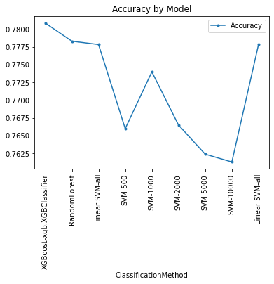

```python
combinedResultsDf.plot(x="ClassificationMethod", y="Accuracy", kind="line", style=".-", rot=90)
plt.title('Accuracy by Model')
plt.show()
```

## Results - Training Duration in Seconds

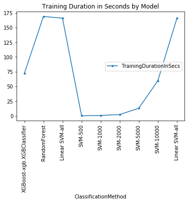

```python
combinedResultsDf.plot(x="ClassificationMethod", y=["TrainingDurationInSecs"], kind="line", style=".-", rot=90)
plt.title('Training Duration in Seconds by Model')
plt.show()
```

## Results - Model to Training Duration/Accuracy

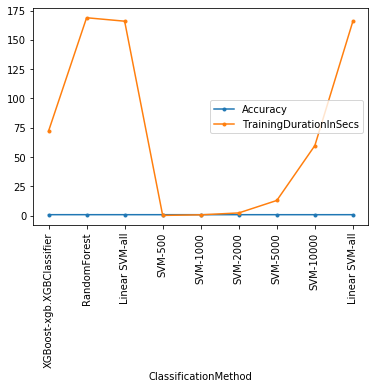

```python
combinedResultsDf.plot(x="ClassificationMethod", y=["Accuracy", "TrainingDurationInSecs"], kind="line", style=".-", rot=90)
```